# R Notebook

## Step 8: Carry out linear dimensional reduction

This serves as a means determine the relationship between cells from the dataset, using expression patterns from the HVG

```r
mydata.E14.5 <- RunPCA(mydata.E14.5, features = VariableFeatures(object = mydata.E14.5))

# check top features in each principal component
print(mydata.E14.5[["pca"]], dims = 1:5, nfeatures = 5)
```

```
PC_ 1
Positive:  GM10800, SLX1B, SLC17A9, ZFP238, NGP
Negative:  CCT8, ARL6IP1, SKP1A, MAPK1, MDH1
PC_ 2
Positive:  ARPC5, 1500032L24RIK, 6330403K07RIK, 2310036O22RIK, MKRN1
Negative:  ZFP367, RBM26, MKI67, TOP2A, GM10800
PC_ 3
Positive:  RANBP1, H2AFV, HAT1, RFC4, RHEB
Negative:  NRXN3, RUNX1T1, DCX, MAF, TUBB3
PC_ 4
Positive:  CENPE, ELAVL4, CENPF, BIRC5, TUBB3
Negative:  TTYH2, PLTP, SLC1A3, ATP1A2, TFPI
PC_ 5
Positive:  TFPI, X99384, BGN, EPAS1, SEPP1
Negative:  SLC1A3, VCAM1, EPHB1, EDNRB, MEIS2
```

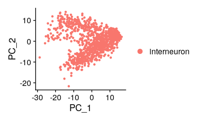

```r
# plot PCA
DimPlot(mydata.E14.5, reduction = "pca", group.by = "old.ident")
```

```r
# Inspect statistics of principal compenents
mydata.E14.5 <- JackStraw(mydata.E14.5, num.replicate = 100)
```

[output not shown]

[output cut: 68 more lines]

[output not shown]

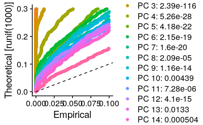

```r
mydata.E14.5 <- ScoreJackStraw(mydata.E14.5, dims = 1:20)
JackStrawPlot(mydata.E14.5, dims = 1:15)
```

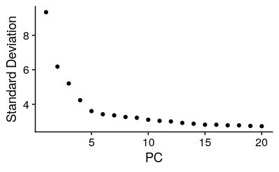

```r
ElbowPlot(mydata.E14.5)
```

## Step 9: Cluster cells

```r
mydata.E14.5 <- FindNeighbors(mydata.E14.5, dims = 1:12)
mydata.E14.5 <- FindClusters(mydata.E14.5, resolution = 0.8)
```

```
Modularity Optimizer version 1.3.0 by Ludo Waltman and Nees Jan van Eck

Number of nodes: 1014
Number of edges: 33999

Running Louvain algorithm...
```

```
Maximum modularity in 10 random starts: 0.7797
Number of communities: 7
Elapsed time: 0 seconds
```

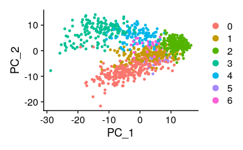

```r
# colour code cells based on cluster
DimPlot(mydata.E14.5, reduction = "pca")
```

## Step 10: Carry out non-linear dimensional reduction

Cell clusters from the PCA plot can be further segragated using non-linear dimensional reduction. We will try both tSNE and UMAP to see how the plot looks like.

```r
mydata.E14.5 <- RunTSNE(mydata.E14.5, dims = 1:10)
mydata.E14.5 <- RunUMAP(mydata.E14.5, dims = 1:12)

# group cells based on its proliferative state
tmp.dat <- mydata.E14.5[[]]
tmp.dat <- tmp.dat %>%
  mutate(State = ifelse(Phase == "G1", "Non-proliferative","Proliferative"))
mydata.E14.5[["State"]] <- tmp.dat$State


DimPlot(mydata.E14.5, reduction = "tsne")
DimPlot(mydata.E14.5, reduction = "tsne", group.by = "CellType")
DimPlot(mydata.E14.5, reduction = "tsne", group.by = "Phase")
#DimPlot(mydata.E14.5, reduction = "umap")


DimPlot(mydata.E14.5, reduction = "tsne", group.by = "State")
FeaturePlot(mydata.E14.5, features = head(g2m.genes,12), reduction = "tsne")
```

[output not shown]

## Step 11: Find Biomarkers

For each clusters, we want to determine the group of genes that define that cell type and later infer the cell identity.

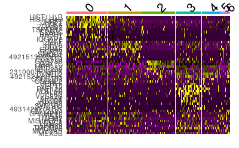

```r
mydata.E14.5.markers <- FindAllMarkers(mydata.E14.5, test.use = "negbinom", only.pos = TRUE, min.pct = 0.25, logfc.threshold = 1.5)
# get top 10 markers from each cluster
top10 <- mydata.E14.5.markers %>% group_by(cluster) %>% top_n(n = 10, wt = avg_logFC)


#Plot heatmap of marker expression in all cells
DoHeatmap(mydata.E14.5, features = top10$gene) + NoLegend()
```

## Step 12: export cell clusters